# act_report

## Report: act_report

- Create a **250-word-minimum written report** called "act_report.pdf" or "act_report.html" that communicates the insights and displays the visualization(s) produced from your wrangled data. This is to be framed as an external document, like a blog post or magazine article, for example.

### Insights

The names of the dogs were programatically extracted from the phrases where the dog's name is expected to come after this format ('This is'), but a lot of terms that weren't the dog's name were also extracted. This lack of dog names was made feasible by the fact that some content has a different format than the line of code used to extract the dog names. The issue was fixed by utilizing the pandas.series.str.extract method to extract just the names that match a dog name, after which the incorrect names were removed. When NaN should have been utilized, the extraction for the dog stages that came under the "doggo," "floofer," "puppo," and "pupper" columns included a value of "None". While there are dogs that can be categorized under more than one breed but that were not adequately defined and separated, the None values were modified. This was remedied by giving each dog a different name while generating the stage column. Because there are gaps in the picture prediction data that cannot be filled without access to the source data, these rows without the missing columns were eliminated. From the analysis of the master dataset, the most frequent dog breed is doggo as most dogs breed fails under this particular stage and the most common source of data used was dog_df_twitter.

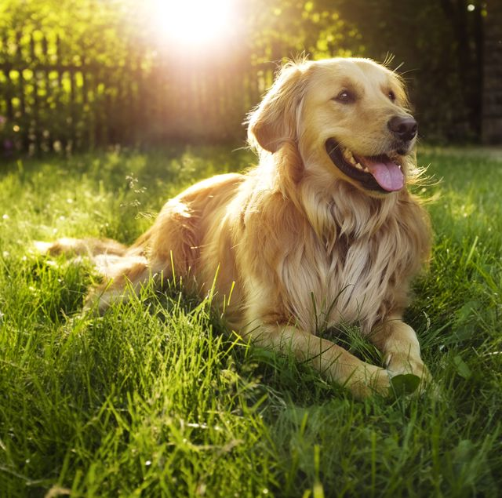

### Visualization

The exploration of the relationships between variables or understanding the underlying structure of the dataset is made possible by the visualization of the data gathered. A seaborn regplot tool was utilized to obtain a visual comprehension between two of the variables (retweet count and favorite count) in the Dataset.

### seaborn.regplot()

Below is a graph of retweet_count against favorite_count. This graph showed a positive correlation between booth variable.

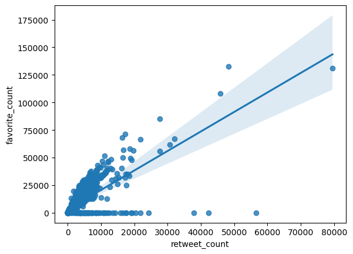